# Observational results:

## Core models:

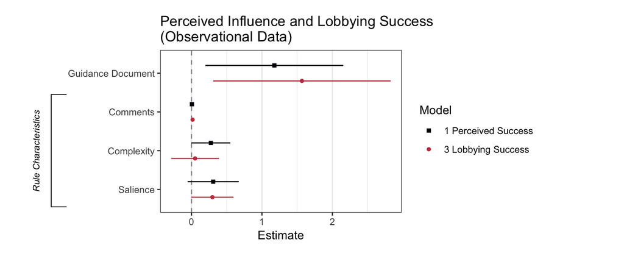

## Expanded models:

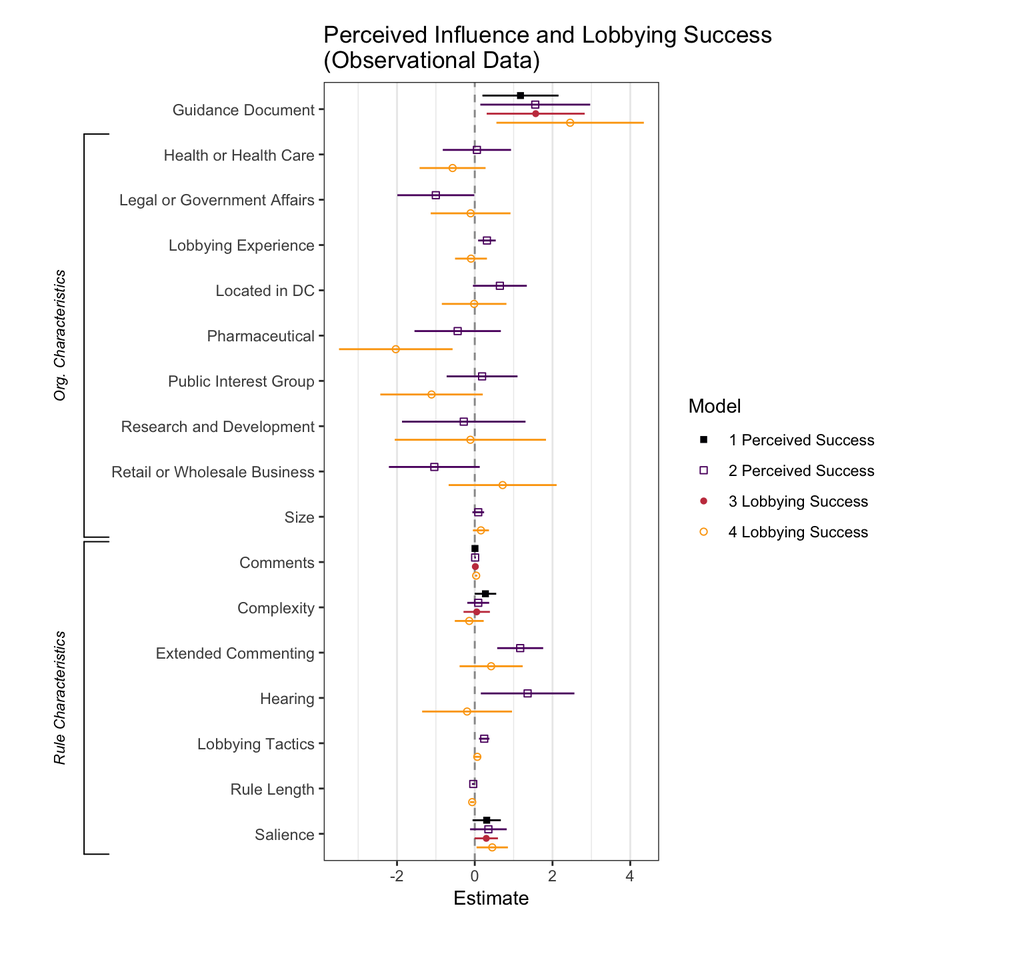

## Only the Guidance coeficients

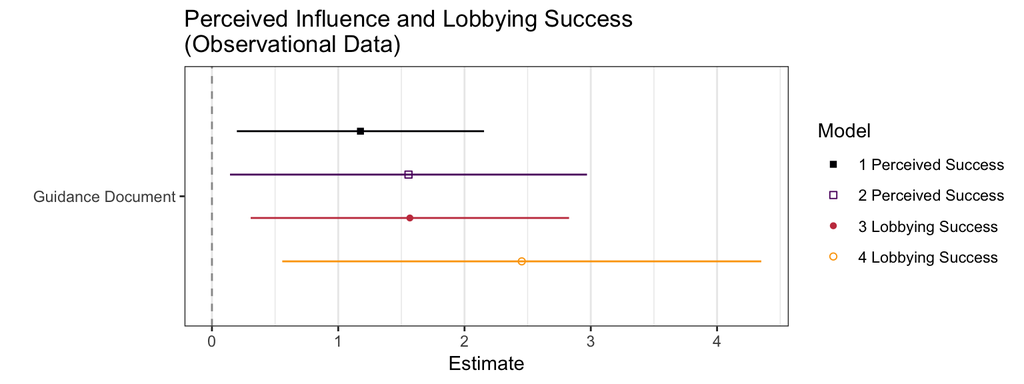

# Experiment Results (dummy)

## Core models:

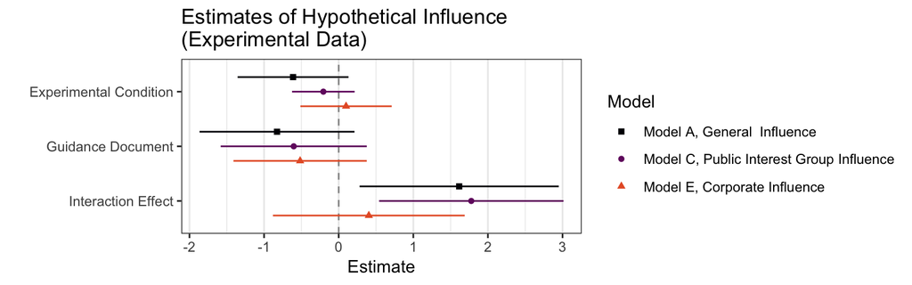

## Expanded models:

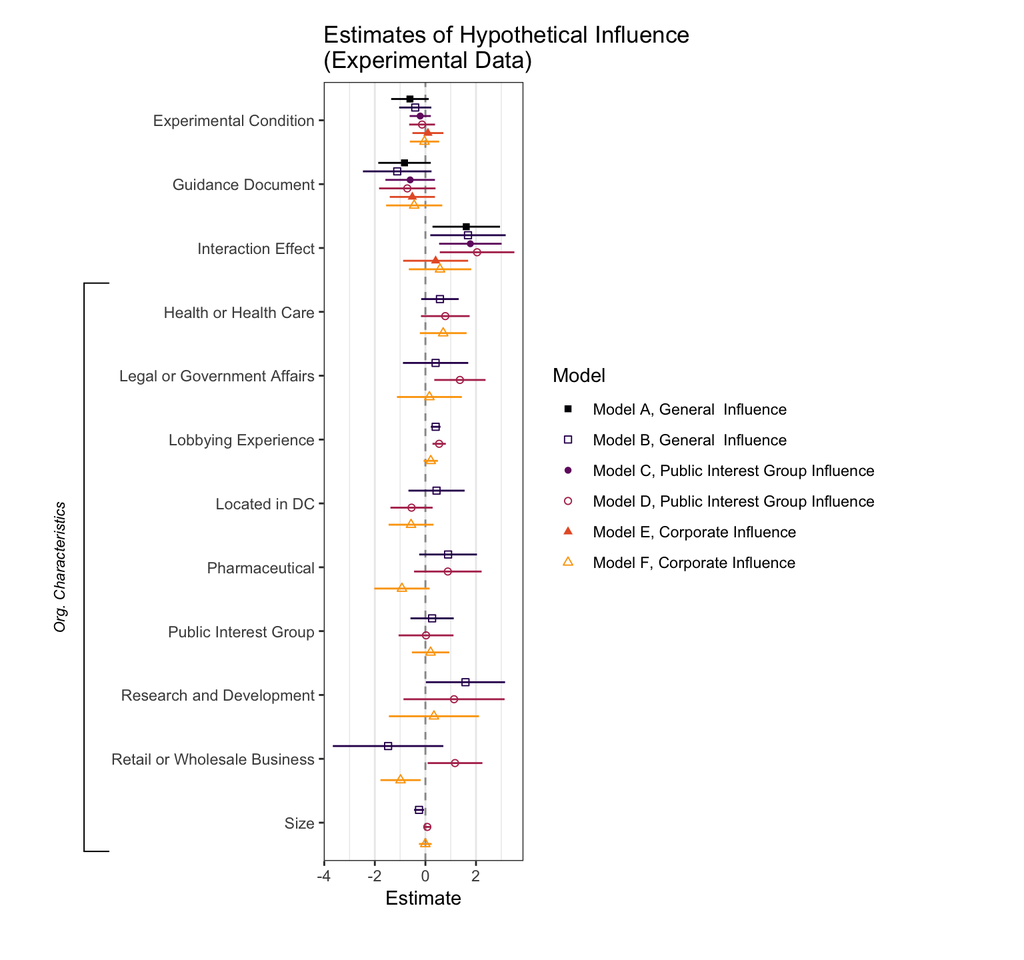

## Interaction

In order to add errors to marginal effects, I need the covariance.

It might be good to show the underlying data, which would look better (and be more accurate) for the 5pt scale, but could be jittered on 1 and 0.

```
## # A tibble: 4 x 3
##   group               condition         estimate
##   <chr>               <chr>                <dbl>
## 1 Lobbied on Guidance Guidance Vignette    0.177
## 2 Lobbied on Rule     Rule Vignette        0
## 3 Lobbied on Rule     Guidance Vignette   -0.612
## 4 Lobbied on Guidance Rule Vignette       -0.827
```

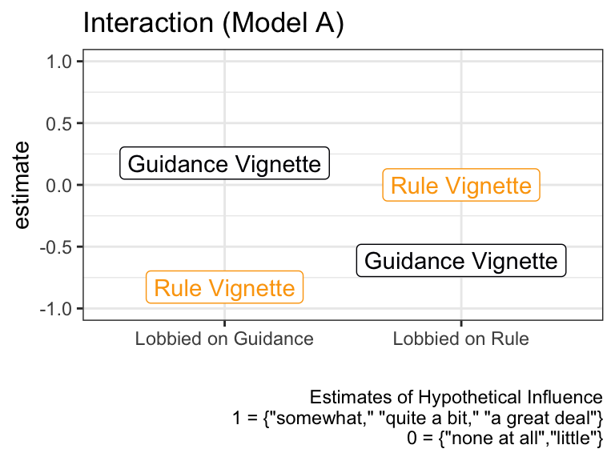

The effect of the **guidance** condition for those that lobbied on **guidance** compared to:

The **rule** condition for those that lobbied on a **rule**: 0.176623

The **guidance** condition for those that lobbied on a **rule**: 0.78819

The **rule** condition for those that lobbied on **guidance**: 1.003293

# Experiment Results (5 point)

## Core models:

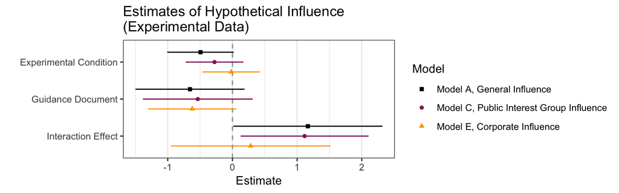

## Interaction

```
## # A tibble: 4 x 3
##   group               condition         estimate
##   <chr>               <chr>                <dbl>
## 1 Lobbied on Guidance Guidance Vignette   0.0155
## 2 Lobbied on Rule     Rule Vignette       0
## 3 Lobbied on Rule     Guidance Vignette  -0.494
## 4 Lobbied on Guidance Rule Vignette      -0.657
```

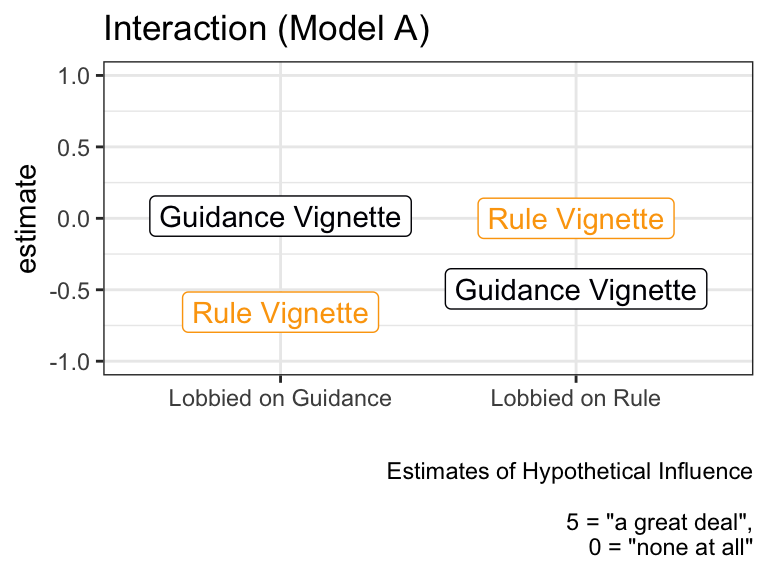

For refrence: For 𝑌=𝑏0+𝑏1𝑋+𝑏2𝑍+𝑏3𝑋𝑍+𝑒 , the marginal effect is 𝑏1+𝑏3⋅𝑍, a function of 𝑍. The variance of a weighted sum is 𝑉𝑎𝑟(𝑏1)+𝑉𝑎𝑟(𝑏3)⋅𝑍2+2⋅𝑍⋅𝐶𝑜𝑣(𝑏1,𝑏3), and the standard error is just the square root of that. You can get the covariance from the right off-diagonal element of the variance-covariance matrix of the coefficients. The variances will be found on the diagonal.

# Citations

Anthony (1992)

F. R. Baumgartner (2009)

F. R. Baumgartner and Jones (1993)

F. R. Baumgartner and Leech (2001)

Bentham (1843)

Browne (1990)

D. P. Carpenter (2002)

D. P. Carpenter and Moss (2014)

Coglianese, Kilmartin, and Mendelson (2009)

Davis (1971)

Dür and De Bièvre (2007)

Epstein and O’Halloran (1995)

Food and Drug Administration (2011)

Franklin (2010)

Funk (2001)

Scott R. Furlong (1998)

Scott. R. Furlong and Kerwin (2005)

Garrett and Vermeule (2006)

Gluck, Po, and Joseph O’connell (2015)

Golden (1998)

Graham and Broughel (2015)

Greve and Parrish (2014)

Haeder and Yackee (2015)

Hojnacki et al. (2012)

Hickman (2009)

Hrebenar and Scott (1996)

Hwang et al. (2014)

Kaufman (1981)

Kaufman (2001)

Kerwin and Furlong (2018)

Kingdon (1995)

Klüver (2013)

Levin (2018)

Lewis (2011)

Magill (2004)

Mahoney (2007)

Manning (1996)

Mantel (2009)

McCubbins, Noll, and Weingast (1987)

McCubbins, Noll, and Weingast (1987)

N. Mendelson (2007)

Naughton et al. (2009)

Office of Management and Budget (2007)

Parrillo (2019)

Romano (2014)

Romano (2018)

Raso (2010)

Rourke (1984)

Rosenbloom (2000)

Sabatier (1988)

Schattschneider (1975)

Seidenfeld (2011)

Shapiro (2014)

Stack (2016)

Truman (1951)

Warren (2011)

West (1995)

West (2004)

Yackee (2019)

J. W. Yackee and Yackee (2006)

Young, Marple, and Heilman (2017)

# Bibliography

Anthony, Robert A. 1992. “Interpretive Rules, Policy Statements, Guidances, Manuals, and the Like-Should Federal Agencies Use them to Bind the Public.” *Duke Law Journal* 41 (6): 1311–84. https://heinonline.org/HOL/Page?handle=hein.journals/duklr41{\&}div=45{\&}g{\_}sent=1{\&}casa{\_}token={\&}collection=journals.

Baumgartner, Frank R. 2009. *Lobbying and Policy Change: Who Wins, Who Loses, and Why*. University of Chicago Press.

Baumgartner, Frank R., and Bryan D. Jones. 1993. *Agendas and Instability in American Politics*. Vol. 56. 4. doi:10.2307/2132088.

Baumgartner, Frank R., and Beth L. Leech. 2001. *Basic Interests: The Importance of Groups in Politics and in Political Science.* Princeton University Press. https://books.google.com/books?id=X7tkMfttEjoC{\&}dq=baumgartner+and+leech{\&}source=gbs{\_}navlinks{\_}s.

Bentham, Jeremy. 1843. *The Works of Jeremy Bentham: Volume II Published on the Executor John Bowring.* Edited by John Bowring. London, England: Simpkin, Marshall, & Co.

Browne, William P. 1990. “Organized Interests and Their Issue Niches: A Search for Pluralism in a Policy Domain.” *The Journal of Politics* 52 (2): 477–509. doi:10.2307/2131903.

Carpenter, Daniel P. 2002. “Groups, the Media, Agency waiting Costs, and FDA Drug Approval.” *American Journal of Political Science*, 490–505.

Carpenter, Daniel P, and David A Moss. 2014. *Preventing Regulatory Capture: Special Interest Influence and How to Limit It*. Cambridge University Press. doi:10.1017/CBO9781139565875.

Coglianese, Cary, Heather Kilmartin, and Evan Mendelson. 2009. “Transparency and Public Participation in the Rulemaking Process.” *George Town Law Review* 77 (June): 924. https://scholarship.law.upenn.edu/faculty{\_}scholarship/238.

Davis, Kenneth Culp. 1971. “Administrative Law Treatise. 1970 Supplement.” In *Administrative Law Treatise. 1970 Supplement*, 1st ed. St. Paul, MN: West. https://trove.nla.gov.au/work/8849172?q{\&}sort=holdings+desc{\&}{\_}=1553482169452{\&}versionId=18275053.

Dür, Andreas, and Dirk De Bièvre. 2007. “The Question of Interest Group Influence.” *Journal of Public Policy* 27 (1): 1–12. doi:10.1017/S0143814X07000591.

Epstein, David, and Sharyn O’Halloran. 1995. “A Theory of Strategic Oversight: Congress, Lobbyists, and the Bureaucracy.” *The Journal of Law, Economics, and Organization* 11 (2). Narnia: 227–55. doi:10.1093/oxfordjournals.jleo.a036871.

Food and Drug Administration. 2011. “Advancing Regulatory Science: Strategic Plan for Regulatory Science.” Food; Drug Administration. http://www.fda.gov/ScienceResearch/SpecialTopics/RegulatoryScience/ucm267719.htm.

Franklin, David L. 2010. “Legislative Rules, Nonlegislative Rules, and the Perils of the Short Cut.” *Yale Law Journal* 120 (2): 2010. http://digitalcommons.law.yale.edu/ylj/vol120/iss2/2.

Funk, William F. 2001. “A Primer on Nonlegislative Rules.” *Administrative Law Review* 53 (1321-1352). doi:10.2139/ssrn.292269.

Furlong, Scott R. 1998. “Political Influence on the Bureaucracy: The Bureaucracy Speaks.” *Journal of Public Administration Research and Theory* 8 (1). Oxford University Press: 39–65. doi:10.1093/oxfordjournals.jpart.a024373.

Furlong, Scott. R., and Cornelius M. Kerwin. 2005. “Interest Group Participation in Rule Making: A Decade of Change.” *Journal of Public Administration Research and Theory* 15 (3). Oxford University Press: 353–70. doi:10.1093/jopart/mui022.

Garrett, Elizabeth, and Adrian Vermeule. 2006. “Transparency in the Budget Process.” University of Chicago Law & Economics, Olin Working Paper. doi:10.2139/ssrn.877951.

Gluck, Abbe R., Rosa. Po, and Ann Joseph O’connell. 2015. “Yale Law School Yale Law School Legal Scholarship Repository Faculty Scholarship Series Yale Law School Faculty Scholarship.” *Columbia Law Review* 115: 1789–1865. http://digitalcommons.law.yale.edu/fss{\_}papers/5179.

Golden, Marissa Martino. 1998. “Interest Groups in the Rule-Making Process: Who Participates? Whose Voices Get Heard?” *Journal of Public Administration Research and Theory* 8 (2): 245–70.

Graham, John D., and James Broughel. 2015. “Confronting the Problem of Stealth Regulation.” Mercatus Center. https://www.mercatus.org/publication/confronting-problem-stealth-regulation.

Greve, Michael, and Ashley Parrish. 2014. “Administrative Law Without Congress.” *George Mason Law Review* 22 (3). https://papers.ssrn.com/sol3/papers.cfm?abstract{\_}id=2514484.

Haeder, Simon F., and Susan Webb Yackee. 2015. “Influence and the Administrative Process: Lobbying the U.S. President’s Office of Management and Budget.” *American Political Science Review* 109 (03). Cambridge University Press: 507–22. doi:10.1017/S0003055415000246.

Hickman, Kristin E. 2009. “IRB Guidance: The No Man’s Land of Tax Code Interpretation.” *Michigan State Law Review* 239. http://scholarship.law.umn.edu/faculty{\_}articleshttp://scholarship.law.umn.edu/faculty{\_}articles/206.

Hojnacki, Marie, David C Kimball, Frank R Baumgartner, Jeffrey M Berry, and Beth L Leech. 2012. “Studying Organizational Advocacy and Influence: Reexamining Interest Group Research.” *Annual Review of Political Science* 15 (1): 379–99. doi:10.1146/annurev-polisci-070910-104051.

Hrebenar, Ronald J., and Ruth K. Scott. 1996. *Interest Group Politics in America*. 3rd ed. New York, NY: Routledge. doi:10.4324/9781315703381.

Hwang, Thomas J, Jerry Avorn, Daniel Carpenter, and Aaron S Kesselheim. 2014. “Quantifying The Food And Drug Administration’s Rulemaking Delays Highlights The Need For Transparency.” *Health Affairs* 33: 309–15. doi:10.1377/hlthaff.2013.0564.

Kaufman, Herbert. 1981. “The Confines of Leadership.” In *The Administrative Behavior of Federal Bureau Chiefs*, 91–138. Washington, DC: Brookings Institution.

———. 2001. “Major Players: Bureaucracies in American Government.” *Public Administration Review* 61 (1). John Wiley & Sons, Ltd (10.1111): 18–42. doi:10.1111/0033-3352.00003.

Kerwin, Cornelius M., and Scott R. Furlong. 2018. *Rulemaking: How Government Agencies Write Law and Make Policy*. 5th ed. Washington, DC: CQ Press. https://books.google.com/books?id=0O1bDwAAQBAJ{\&}dq=Kerwin,+Cornelius+M.,+and+Scott+R.+Furlong.+2018.+Rulemaking:+How+Government+Agencies+Write+Law+and+Make+Policy,+5th+ed.+Washington,+DC:+CQ+Press.{\&}source=gbs{\_}navlinks{\_}s.

Kingdon, John W. 1995. *Agendas, Alternatives, and Public Policies*. 2nd ed. New York: HarperCollins College Publishers.

Klüver, Heike. 2013. *Lobbying in the European Union: Interest Groups, Lobbying Coalitions, and Policy Change*. Oxford, England: Oxford University Press.

Levin, Ronald M. 2018. “Rulemaking and the Guidance Exemption.” *Administrative Law Review* 70 (2): 263–356. http://www.administrativelawreview.org/wp-content/uploads/2018/10/ALR-70.2{\_}Levin.pdf.

Lewis, Kevin Michael. 2011. “Informal Guidance and the FDA.” *Food and Drug Law Journal* 66 (4): 507–50, i. http://www.ncbi.nlm.nih.gov/pubmed/24505827.

Magill, Elizabeth M. 2004. “Agency Choice of Policymaking Form.” *University of Chicago Law Review* 71 (4). The University of Chicago Law Review. https://chicagounbound.uchicago.edu/uclrev/vol71/iss4/2.

Mahoney, Christine. 2007. “Lobbying Success in the United States and the European Union Author.” 1. Vol. 27. https://www.jstor.org/stable/4007826.

Manning, John F. 1996. “Constitutional Structure and Judicial Deference to Agency Interpretations of Agency Rules.” *Columbia Law Review* 96 (3): 612–96. https://about.jstor.org/terms.

Mantel, Jessica. 2009. “Procedural Safeguards for Agency Guidance.” *Administrative Law Review*, 343–406. http://www.administrativelawreview.org/wp-content/uploads/2014/04/Procedural-Safeguards-for-Agency-Guidance-A-Source-of-Legitimacy-for-the-Administrative-State.pdf.

McCubbins, Mathew D., Roger G. Noll, and Barry R. Weingast. 1987. “Administrative Procedures as Instruments of Political Control.” *Journal of Law, Economics, & Organization* 3 (2): 243–77. doi:10.1093.

Mendelson, Nina. 2007. “Regulatory Beneficiaries and Informal Agency Policymaking.” *Cornell Law Review* 92 (3): 397–452. https://www.researchgate.net/publication/6410686{\_}Regulatory{\_}beneficiaries{\_}and{\_}informal{\_}agency{\_}policymaking.

Naughton, Keith, Celeste Schmid, Susan Webb Yackee, and Xueyong Zhan. 2009. “Understanding Commenter Influence during Agency Rule Development.” WileyAssociation for Public Policy Analysis; Management. doi:10.2307/29739013.

Office of Management and Budget. 2007. “Final Bulletin for Agency Good Guidance Practices, No. 07-02.” http://www.whitehouse.gov/omb/inforeg/good{\_}guid/c-index.html.

Parrillo, Nicholas R. 2019. “Federal Agency Guidance and the Power to Bind: An Empirical Study of Agencies and Industries.” *Yale Journal on Regulation* 36: 165–271. https://www.acus.gov/sites/default/files/documents/parrillo-agency-guidance-final-report.pdf.

Raso, Connor N. 2010. “Strategic or Sincere? Analyzing Agency Use of Guidance Documents.” *Yale Law Journal* 119 (4): 648–847. https://www.yalelawjournal.org/note/agency-use-of-guidance-documents.

Romano, Roberta. 2014. “Regulating in the Dark and a Postscript Assessment of the Iron Law of Financial Regulation.” *Hofstra Law Review* 43 (1). https://scholarlycommons.law.hofstra.edu/hlr/vol43/iss1/2.

———. 2018. “Does Agency Structure Affect Agency Decisionmaking? Implications of the CFPB’s Design for Administrative Governance.” Yale Law & Economics Research Paper. doi:10.2139/ssrn.3096356.

Rosenbloom, David H. 2000. *Framing Legislative Centered Public Administration: Congress ’s 1946 Response to the Administrative State.* University of Alabama Press. http://www.uapress.ua.edu/product/Building-a-Legislative-Centered-Public-Administrat,1271.aspx.

Rourke, Francis E. 1984. *Bureaucracy, Politics, and Public Policy.* 3nd ed. Boston, MA: Little, Brown. doi:10.1177/000271626938500151.

Sabatier, Paul A. 1988. “An Advocacy Coalition Framework of Policy Change and the Role of Policy-Oriented Learning Therein.” Vol. 21. https://about.jstor.org/terms.

Schattschneider, Elmer E. 1975. *The Semisovereign People: A Realist’s Wiew of Democracy in America*. Revised. Dryden Press. http://wikisum.com/w/Schattschneider:{\_}The{\_}semisovereign{\_}people https://books.google.com/books/about/The{\_}semisovereign{\_}people.html?id=GXdHAAAAMAAJ.

Seidenfeld, Mark B. 2011. “Substituting Substantive for Procedural Review of Guidance Documents.” *Texas Law Review* 90: 331–94. doi:10.2139/ssrn.1748731.

Shapiro, Stuart. 2014. “Agency Oversight as Whac-A-Mole: The Challenge of Restricting Agency Use of Nonlegislative Rules.” *Harvard Journal of Law and Public Policy* 37 (2). Harvard Society for Law; Public Policy, Inc: 523–52. https://www.researchwithnj.com/en/publications/agency-oversight-as-whac-a-mole-the-challenge-of-restricting-agen.

Stack, Kevin M. 2016. “Preambles as Guidance.” *The George Washington Law Review* 84 (5): 1252. https://www.gwlr.org/preambles-as-guidance/.

Truman, David B. 1951. *The Governmental Process. Political Interests and Public Opinion*. New York, NY: Alfred A. Knopf. doi:10.1002/ncr.4110400915.

Warren, Kenneth F. 2011. *Administrative Law in the Political System*. 5th ed. Boulder, CO: Westview Press. https://www.worldcat.org/title/administrative-law-in-the-political-system/oclc/680620954.

West, William F. 1995. *Controlling the Bureaucracy: Institutional Constraints in Theory and Practice*. M.E. Sharpe. https://books.google.com/books?id=eizlpF7uOQcC{\&}source=gbs{\_}navlinks{\_}s.

———. 2004. “Formal Procedures, Informal Processes, Accountability, and Responsiveness in Bureaucratic Policy Making: An Institutional Policy Analysis.” *Public Administration Review* 64 (1). Wiley/Blackwell (10.1111): 66–80. doi:10.1111/j.1540-6210.2004.00347.x.

Yackee, Jason Webb, and Susan Webb Yackee. 2006. “A Bias Towards Business? Assessing Interest Group Influence on the U.S. Bureaucracy.” *Journal of Politics* 68 (1): 128–39.

Yackee, Susan Webb. 2019. “The Politics of Rulemaking in the United States.” *Annual Review of Political Science* 22 (1). doi:10.1146/annurev-polisci-050817-092302.

Young, Kevin L., Tim Marple, and James Heilman. 2017. “Beyond the Revolving Door: Advocacy Behavior and Social Distance to Financial Regulators.” *Business and Politics* 19 (02). Cambridge University Press: 327–64. doi:10.1017/bap.2017.10.